# Decision Tree

Carlos Grande Nuñez, Veronica Gomez Gomez y Pablo Olmos Martinez

30/04/2020

# Libraries and functions

## Libraries

```r
# basics
library(dplyr)
library(ggplot2)
library(tidyr)
library(kableExtra)
# C50 tree
library(gmodels)
library(C50)
library(partykit)
library(caret)
library(lattice)
```

## Functions

```r
split_data <- function(data, trn = .6, tst = .2, val = .2) {
  set.seed(737)
  spec = c(train = trn, test = tst, validate = val)
  # cutter
  g = sample(cut(seq(nrow(data)), nrow(data)*cumsum(c(0,spec)), labels = names(spec)))
  # spliter
  data <- split(data, g)
  return(data)
}

p_barras <-function(df, dx, xlab){
p = ggplot(df, aes(unlist(dx), fill=unlist(dx))) +
  geom_bar(position="dodge", fill='#8bbabb', color="#464159") +
  labs(x= xlab, y = 'Frecuencia', fill=NULL) +
  ggtitle("Diagrama de barras")
return(p)
}
```

# 1 Loading Data

## 1.1 Reading the Data from the CSV

```r
file <- 'cluster.csv'
df_houses <-  read.csv(file)
head(df_houses) %>% kable() %>% kable_styling() %>% scroll_box(width = "100%", height = TRUE)
```

| X.2 | X.1 | X | Y | id | date | price | bedrooms | bathrooms | sqft_living | sqft_lot | floors | waterfront | view | condition | grade | sqft_above | sqft_basement | yr_built | yr_renovated | zipcode | lat | long | sqft_living15 | sqft_lot15 | cluster | hclust | Cluster_final |
| --- | --- | --- | --- | --- | --- | --- | --- | --- | --- | --- | --- | --- | --- | --- | --- | --- | --- | --- | --- | --- | --- | --- | --- | --- | --- | --- | --- |
| 1 | 1 | 3.7621642 | 22.445021 | 7129300520 | 10/13/2014 | 221900 | 3 | 1.00 | 1180 | 5650 | 1 | 0 | 0 | 3 | 7 | 1180 | 0 | 1955 | 0 | 98178 | 47.5112 | -122.257 | 1340 | 5650 | 1 | 1 | low |
| 2 | 2 | -24.0359753 | 9.766915 | 6414100192 | 12/9/2014 | 538000 | 3 | 2.25 | 2570 | 7242 | 2 | 0 | 0 | 3 | 7 | 2170 | 400 | 1951 | 1991 | 98125 | 47.7210 | -122.319 | 1690 | 7639 | 1 | 2 | top |
| 3 | 3 | 5.2170153 | 8.102678 | 5631500400 | 2/25/2015 | 180000 | 2 | 1.00 | 770 | 10000 | 1 | 0 | 0 | 3 | 6 | 770 | 0 | 1933 | 0 | 98028 | 47.7379 | -122.233 | 2720 | 8062 | 1 | 3 | med |
| 4 | 4 | 7.5887297 | 18.967730 | 2487200875 | 12/9/2014 | 604000 | 4 | 3.00 | 1960 | 5000 | 1 | 0 | 0 | 5 | 7 | 1050 | 910 | 1965 | 0 | 98136 | 47.5208 | -122.393 | 1360 | 5000 | 2 | 1 | low |
| 5 | 5 | 0.6661815 | 3.939548 | 1954400510 | 2/18/2015 | 510000 | 3 | 2.00 | 1680 | 8080 | 1 | 0 | 0 | 3 | 8 | 1680 | 0 | 1987 | 0 | 98074 | 47.6168 | -122.045 | 1800 | 7503 | 3 | 3 | med |
| 6 | 6 | -2.6542516 | -26.720289 | 7237550310 | 5/12/2014 | 1230000 | 4 | 4.50 | 5420 | 101930 | 1 | 0 | 0 | 3 | 11 | 3890 | 1530 | 2001 | 0 | 98053 | 47.6561 | -122.005 | 4760 | 101930 | 3 | 4 | med |

## 1.2 Adding a binary target

```r
quantile <- df_houses$price %>% quantile(0.75)
df_houses$target <- ifelse(df_houses$price>quantile, 'p75', 'n75')
df_houses <- df_houses %>% select(6, 8:25, 28:29)
table(df_houses$target)
```

```
##
##   n75   p75
## 16226  5371
```

```r
head(df_houses) %>% kable() %>% kable_styling() %>% scroll_box(width = "100%", height = TRUE)
```

| date | bedrooms | bathrooms | sqft_living | sqft_lot | floors | waterfront | view | condition | grade | sqft_above | sqft_basement | yr_built | yr_renovated | zipcode | lat | long | sqft_living15 | sqft_lot15 | Cluster_final | target |
| --- | --- | --- | --- | --- | --- | --- | --- | --- | --- | --- | --- | --- | --- | --- | --- | --- | --- | --- | --- | --- |
| 10/13/2014 | 3 | 1.00 | 1180 | 5650 | 1 | 0 | 0 | 3 | 7 | 1180 | 0 | 1955 | 0 | 98178 | 47.5112 | -122.257 | 1340 | 5650 | low | n75 |
| 12/9/2014 | 3 | 2.25 | 2570 | 7242 | 2 | 0 | 0 | 3 | 7 | 2170 | 400 | 1951 | 1991 | 98125 | 47.7210 | -122.319 | 1690 | 7639 | top | n75 |
| 2/25/2015 | 2 | 1.00 | 770 | 10000 | 1 | 0 | 0 | 3 | 6 | 770 | 0 | 1933 | 0 | 98028 | 47.7379 | -122.233 | 2720 | 8062 | med | n75 |
| 12/9/2014 | 4 | 3.00 | 1960 | 5000 | 1 | 0 | 0 | 5 | 7 | 1050 | 910 | 1965 | 0 | 98136 | 47.5208 | -122.393 | 1360 | 5000 | low | n75 |
| 2/18/2015 | 3 | 2.00 | 1680 | 8080 | 1 | 0 | 0 | 3 | 8 | 1680 | 0 | 1987 | 0 | 98074 | 47.6168 | -122.045 | 1800 | 7503 | med | n75 |
| 5/12/2014 | 4 | 4.50 | 5420 | 101930 | 1 | 0 | 0 | 3 | 11 | 3890 | 1530 | 2001 | 0 | 98053 | 47.6561 | -122.005 | 4760 | 101930 | med | p75 |

# 2 Exploring preparing the data

## 2.1 Transforming data

```r
# Date as year
df_houses$date <- df_houses$date %>% as.Date("%m/%d/%Y") %>% format("%Y") %>% as.integer()
# waterfront and view as factor
df_houses$waterfront <- df_houses$waterfront %>% as.factor()
df_houses$view <- df_houses$view %>% as.factor()
# cluster to factor
df_houses$Cluster_final <- df_houses$Cluster_final %>% as.factor()
df_houses$target <- df_houses$target %>% as.factor()

head(df_houses) %>% kable() %>% kable_styling() %>% scroll_box(width = "100%", height = TRUE)
```

| date | bedrooms | bathrooms | sqft_living | sqft_lot | floors | waterfront | view | condition | grade | sqft_above | sqft_basement | yr_built | yr_renovated | zipcode | lat | long | sqft_living15 | sqft_lot15 | Cluster_final | target |
| --- | --- | --- | --- | --- | --- | --- | --- | --- | --- | --- | --- | --- | --- | --- | --- | --- | --- | --- | --- | --- |
| 2014 | 3 | 1.00 | 1180 | 5650 | 1 | 0 | 0 | 3 | 7 | 1180 | 0 | 1955 | 0 | 98178 | 47.5112 | -122.257 | 1340 | 5650 | low | n75 |
| 2014 | 3 | 2.25 | 2570 | 7242 | 2 | 0 | 0 | 3 | 7 | 2170 | 400 | 1951 | 1991 | 98125 | 47.7210 | -122.319 | 1690 | 7639 | top | n75 |
| 2015 | 2 | 1.00 | 770 | 10000 | 1 | 0 | 0 | 3 | 6 | 770 | 0 | 1933 | 0 | 98028 | 47.7379 | -122.233 | 2720 | 8062 | med | n75 |
| 2014 | 4 | 3.00 | 1960 | 5000 | 1 | 0 | 0 | 5 | 7 | 1050 | 910 | 1965 | 0 | 98136 | 47.5208 | -122.393 | 1360 | 5000 | low | n75 |
| 2015 | 3 | 2.00 | 1680 | 8080 | 1 | 0 | 0 | 3 | 8 | 1680 | 0 | 1987 | 0 | 98074 | 47.6168 | -122.045 | 1800 | 7503 | med | n75 |
| 2014 | 4 | 4.50 | 5420 | 101930 | 1 | 0 | 0 | 3 | 11 | 3890 | 1530 | 2001 | 0 | 98053 | 47.6561 | -122.005 | 4760 | 101930 | med | p75 |

## 2.2 Spliting the data

```r
data <- split_data(df_houses)
train <- data$train
validation <- data$validate
test <- data$test

x_train <- train %>% select(-target)
y_train <- train$target
x_val <- validation %>% select(-target)
y_val <- validation$target
x_test <- test %>% select(-target)
y_test <- test$target
```

# 2 Decision tree model

## 2.1 Training the model C5.0

```r
# The model
m_tree <- C5.0(x_train, y_train)
m_tree
```

```
##
## Call:
## C5.0.default(x = x_train, y = y_train)
##
## Classification Tree
## Number of samples: 12958
## Number of predictors: 20
##
## Tree size: 121
##
## Non-standard options: attempt to group attributes
```

```r
# summary(m_tree)
```

Evaluation on training data (12958 cases):

```
 Decision Tree
  ----------------
  Size      Errors

   121  766( 5.9%)   <<


   (a)   (b)    <-classified as
  ----  ----
  9481   249    (a): class <p75
   517  2711    (b): class >p75


Attribute usage:

100.00% grade
 99.63% lat
 84.04% waterfront
 61.48% sqft_living
 50.73% zipcode
 47.71% view
 21.15% long
 21.02% yr_built
  8.90% yr_renovated
  8.81% condition
  6.72% sqft_above
  4.19% sqft_lot15
  3.72% bathrooms
  3.61% Cluster_final
  3.56% date
  2.29% bedrooms
  2.27% sqft_living15
  2.05% sqft_lot
  0.69% sqft_basement
  0.23% floors
```

Podemos ver que las 3 variables que más condicionan la clasificación del modelo son la variable *grade* o nota del estado del inmueble la latitud *lat* y si tiene o no vistas a lago o mar.

## 2.2 Plotting the tree

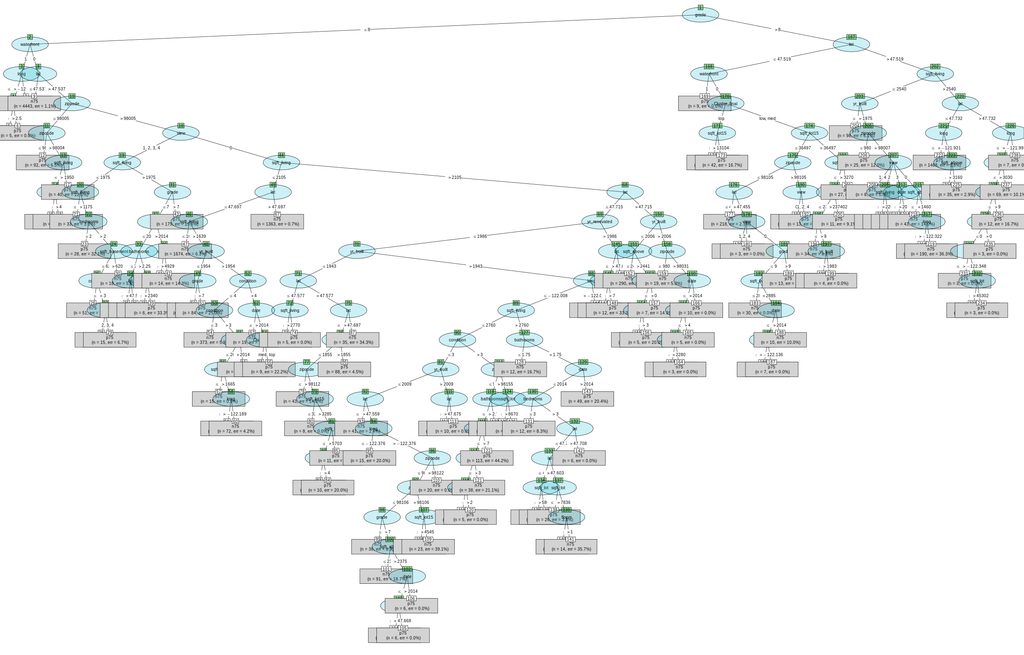

large_tree

## 2.3 Evaluating the model performance on validation

```r
pred <- predict(m_tree, x_val)
table_train <- CrossTable(y_val, pred, prop.chisq = FALSE, prop.c = FALSE, prop.r = FALSE, dnn = c('Actual', 'Precicted'))
```

```
##
##
##    Cell Contents
## |-------------------------|
## |                       N |
## |         N / Table Total |
## |-------------------------|
##
##
## Total Observations in Table:  4320
##
##
##              | Precicted
##       Actual |       n75 |       p75 | Row Total |
## -------------|-----------|-----------|-----------|
##          n75 |      3068 |       172 |      3240 |
##              |     0.710 |     0.040 |           |
## -------------|-----------|-----------|-----------|
##          p75 |       262 |       818 |      1080 |
##              |     0.061 |     0.189 |           |
## -------------|-----------|-----------|-----------|
## Column Total |      3330 |       990 |      4320 |
## -------------|-----------|-----------|-----------|
##
##
```

```r
accuracy <- sum(diag(table_train$t))/sum(table_train$t)
output= sprintf("The test accuracy of the tree is: %s", accuracy)
print(output)
```

```
## [1] "The test accuracy of the tree is: 0.899537037037037"
```

## 2.4 Understanding the tree

### Plotting the tree

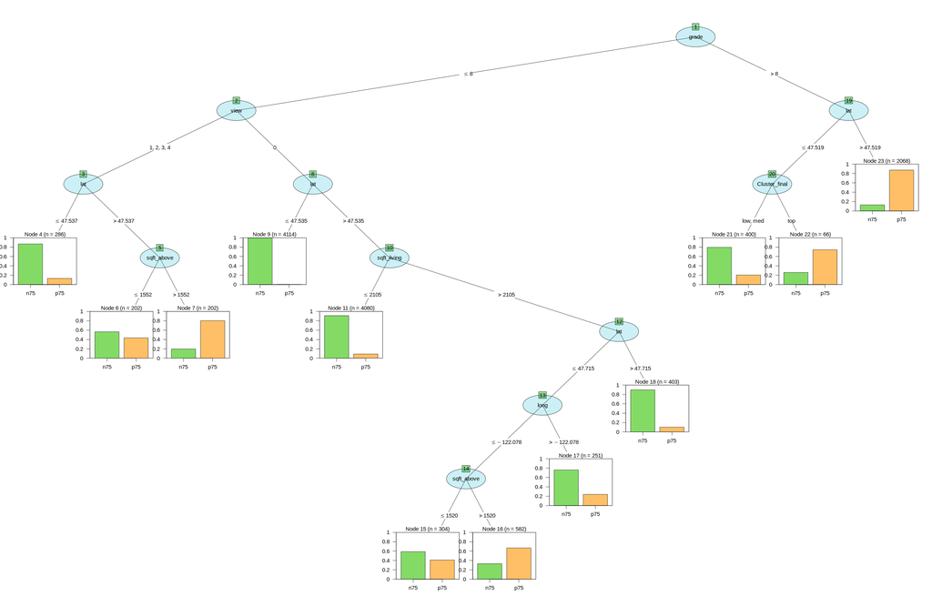

Podrímos concluir lo siguiente a partir de este gráfico:

- Que la mayoría de las viviendas dependen de su variable grade.
- Que aquellas que tienen un *grade* > 8 dependen en su mayoría de su ubicación.
- Que las viviendas con notas más bajas y mala ubicación, dependen mucho de su superficie.

### Declaring rules

Los árboles de decisión pueden ser difíciles de interpretar. Una opción que permite la librería C5.0, es la creación de *rulesets*, una collección de reglas que funcionan como clasificadores. Estas reglas facilitan el entendimiento del árbol de decisión.

```r
m_tree_rules <- C5.0(x_train, y_train, rules = T)
# summary(m_tree)
```

- Rule 1: (2327/7, lift 1.3)  
  zipcode <= 98105 lat <= 47.4552 sqft_lot15 <= 36497 Cluster_final in {low, med}  
  -> class <p75 [0.997]
- Rule 2: (2906/11, lift 1.3)  
  bathrooms <= 2.25 waterfront = 0 grade <= 7 lat <= 47.5685  
  -> class <p75 [0.996]
- Rule 6: (79, lift 1.3)  
  lat > 47.7319 long > -121.997  
  -> class <p75 [0.988]
- Rule 10: (372/16, lift 1.3)  
  sqft_above <= 3160 long > -121.921  
  -> class <p75 [0.955]
- Rule 13: (10424/1296, lift 1.2)  
  grade <= 8  
  -> class <p75 [0.876]

# 3 Improving the model performance

## 3.1 Boosting the accuracy

La función c5.0() nos permite añadir boosting al árbol de decisión mediante el parámetro *trials*. *trials* limita el número de árboles añadidos. Un buen parámetro estándar inicial reconocido para boosting es de 10, ya que algunas investigaciones situan la reducción del error en un 25%. En este caso, ya que el modelo tarda muy poco en ejecutarse probaremos 7 valores diferentes de boosting.

```r
set.seed(737)
trials <- c(5, 10, 15, 20, 25, 30, 40)
results <- c()
for (trial in trials) {
  m_tree_boost <- C5.0(x_train, y_train, trials = trial)
  tree_pred <- predict(m_tree_boost, x_val)
  cm <- table(tree_pred, y_val)
  accuracy <- sum(diag(cm))/sum(cm)
  results <- c(results, accuracy)
}
df_boost <- data.frame(trials = trials, accuracy = results)
df_boost
```

```
##   trials  accuracy
## 1      5 0.9233796
## 2     10 0.9293981
## 3     15 0.9266204
## 4     20 0.9317130
## 5     25 0.9324074
## 6     30 0.9307870
## 7     40 0.9333333
```

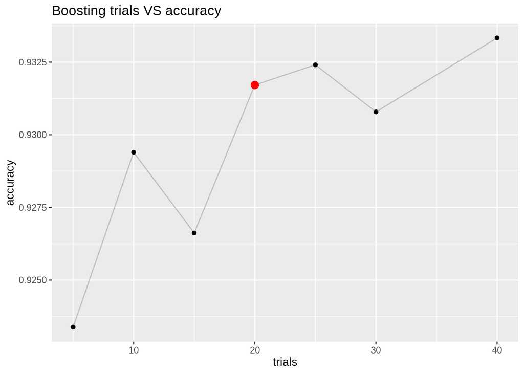

```r
ggplot(data = df_boost, aes(trials, accuracy)) + geom_path(color='grey') + geom_point(color = 'black') + geom_point(color = 'red', size=3, aes(trials[4], accuracy[4])) + labs(title='Boosting trials VS accuracy')
```

```r
m_tree_boost_20 <- C5.0(x_train, y_train, trials = 20)
```

```r
library(pROC)
pred <- predict(m_tree_boost_20, x_val)
prob <- predict(m_tree_boost_20, x_val, type='prob')[, 'p75']
table_train <- CrossTable(y_val, pred, prop.chisq = FALSE, prop.c = FALSE, prop.r = FALSE, dnn = c('Actual', 'Precicted'))
```

```
##
##
##    Cell Contents
## |-------------------------|
## |                       N |
## |         N / Table Total |
## |-------------------------|
##
##
## Total Observations in Table:  4320
##
##
##              | Precicted
##       Actual |       n75 |       p75 | Row Total |
## -------------|-----------|-----------|-----------|
##          n75 |      3125 |       115 |      3240 |
##              |     0.723 |     0.027 |           |
## -------------|-----------|-----------|-----------|
##          p75 |       180 |       900 |      1080 |
##              |     0.042 |     0.208 |           |
## -------------|-----------|-----------|-----------|
## Column Total |      3305 |      1015 |      4320 |
## -------------|-----------|-----------|-----------|
##
##
```

```r
accuracy <- sum(diag(table_train$t))/sum(table_train$t)
output= sprintf("The test accuracy of the tree is: %s", accuracy)
print(output)
```

```
## [1] "The test accuracy of the tree is: 0.931712962962963"
```

```r
library(RMark)
# mymodel=mark(m_tree_boost,threads=1)
# export.model(m_tree_boost, replace = FALSE)
# data(m_tree_boost)
# mymodel=mark(dipper,threads=1)
# export.model(mymodel,replace=TRUE)
```